# Storytelling: Lobbyists4America

Crisitiano Siqueira

2020-12-15

# Client/Hypotheses/Approach

I chose the Lobbyists4America data set so I could gain experience analyzing Twitter data and performing network analysis. Lobbyists4America is a company that provides insights to people who seek to have an influence on legislation in the United States. Lobbyists4America wants me to examine tweets from U.S. Congressional entities over the period of 2008-2017 to understand key topics, members, and relationships.

I found that using retweets, replies, and mentions, and a Walktrap random walk algorithm, I was able to identify communities that correlate with the user’s chamber and political party. This analysis led to the ability to identify the most central users in each community. I used A/B testing to identify which users were statisitically more likely to be amplified by central users. Finally, I looked at the most characterisitic words used by each community. Each of these data points can help Lobbyists4America craft messages to key individuals to influence legislation.

To most fully use the results of this analysis, I recommend Lobbyists4America identify first which party they wish to influence (and possibly which central members they wish to influence), then it could work with the users likely to be amplified by central users. The message should be crafted toward the targeted communities. Republican communities tend to have locally-focused messages and Democratic communities tended to have nationally-focused messages.

# Background

I selected this client because I wanted to learn more about performing network analysis, in particular to understand how to identify the most influential people from an unstructured data source and gaining insights from trend analysis.

I would expect that lobbyists representing groups who want to influence legislation will be interested in learning who are the most influential legislators. It would narrow the number of people they need to convince and make their efforts at persuading the influencers. Looking at the topics these influencers are discussing can alert industry groups to engage quickly or prepare to respond to the new expected legislation.

# Data Wrangling

The data provided consisted of two files with JSON tweet and user objects. There were 1,243,370 tweets between 2008-08-04 and 2017-06-06 from 548 users.

# Exploratory Analysis

The first step in exploring the data is to plot the number of tweets per day and the number of distinct users tweeting per day. In doing so, it is clear that Twitter grew in usage and popularity through mid-2017. While the number of tweets per day appears to increase linearly, the number of users per day seems to have a step increase at the start of each year.

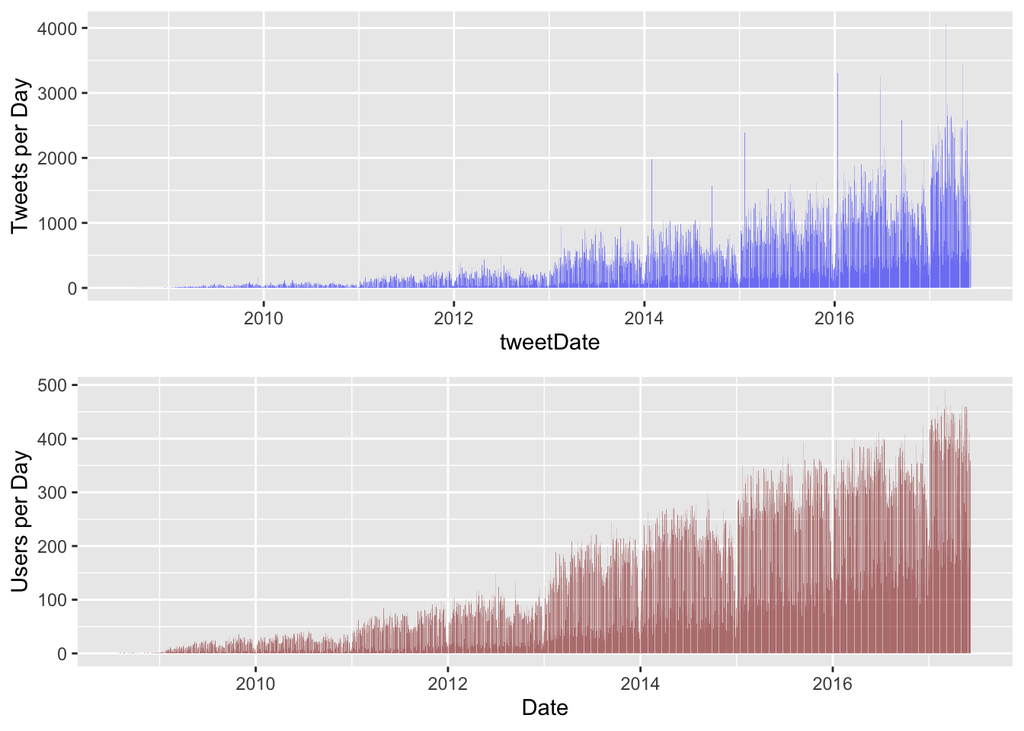

Exploring data at the user level, I looked at audience size, followers, replies, retweets, mentions, and other data points. There seems to be a large and relatively even distribution of users who have had their tweets retweeted. I also observed that there was a high number of outliers with a low number of tweets and the distribution was skewed left. It appeared that replies to other users’ tweets was not as popular among these users as other forms of communication and messaging. Finally, it appeared that there were quite a few outliers with their number of followers, particularly at the high end of the spectrum.

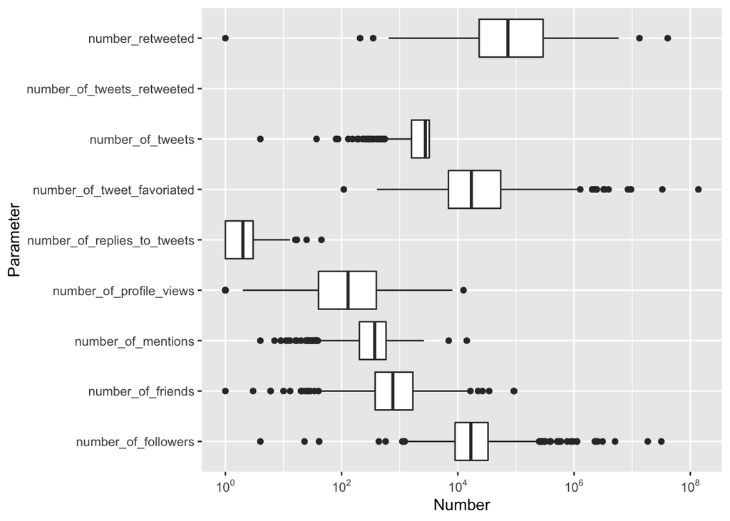

The result seems to indicate that members of the Democratic Party are much more likely to interact with each other and, in particular, members of party leadership to amplify their messages, in particular House Speaker Nancy Pelosi and Senate Minority Leader Chuck Schumer.

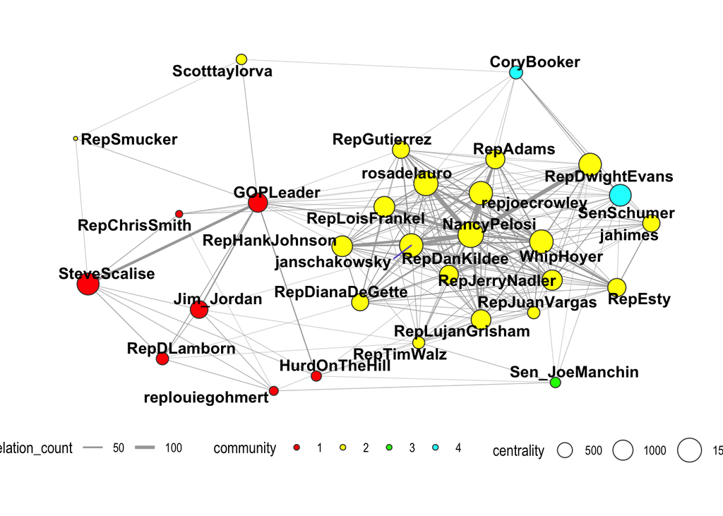

# Hashtags

My initial hypothesis was that I could look at who was the first user to use a hashtag and see which users were the conversation starters. This turned out to be a bad line of analysis, since there did not appear to be enough hashtags growing exponentially for several days to support this analysis. In the data set, there are 79,710 distinct hashtags (this is the case insensitive count). There are 906,530 hashtags used in the 1,243,370 tweets, or 0.7290911 per tweet.

To illustrate this, the top 15 most-used hashtags (from 2016 to the end of the data set) appear in the graph below. Most others tended to be relatively flat and short-lived, or used at a consistent rate over time.

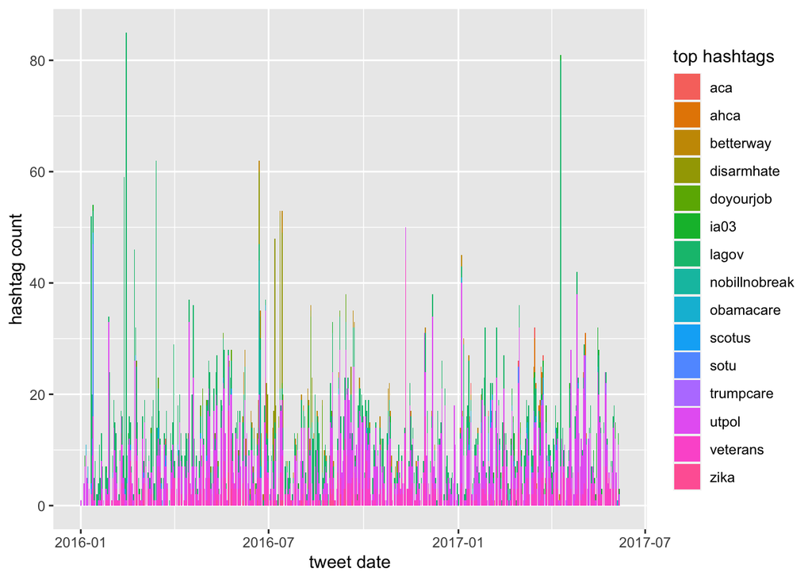

What turned out to be a better line of analysis for hashtags was in looking at term-frequency, indirect document frequency (TF-IDF) as a function of community. TF-IDF highlights terms that are most characteristic of each community by reducing the weight on terms that appear in all communities (the, an, of) in favor of terms that appear in the fewest communities. Here it is clear that Republican House members (community 1) frequently referenced their congressional districts while House Democrats (community 2) tended to tweet about national subjects.

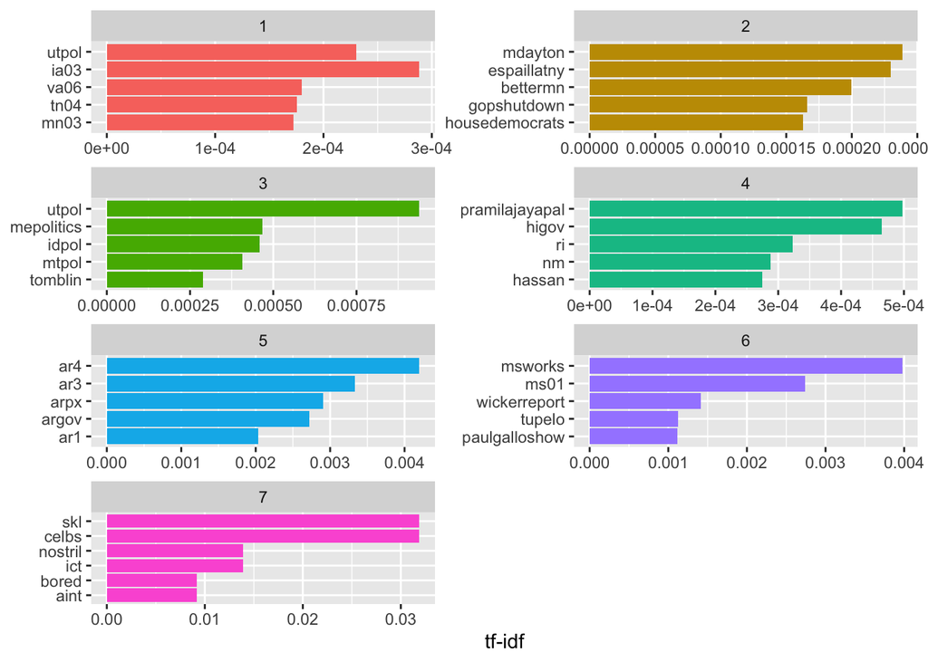

# User Centrality

Under the hypothesis that the most central users are difficult to convince to tweet out your message, I looked at who among the non-central users were most frequently retweeted, mentioned, and replied to by the most central users. Below is a sample of some of the non-central users being amplified by a central user. The number of times a user was mentioned, tweeted, or replied to is the rel_cnt.

```
## # A tibble: 10 x 3
## # Groups:   non_central_user_name_retweeted [9]
##    non_central_user_name_retweeted central_user_retweeting rel_cnt
##    <chr>                           <chr>                     <dbl>
##  1 Dwight Evans                    Governor Tom Wolf           402
##  2 Senator Bob Casey               Donald J. Trump             235
##  3 Ed Markey                       Donald J. Trump             228
##  4 Senator Angus King              Sen. Susan Collins          210
##  5 Mark Warner                     Senator Tim Kaine           183
##  6 Tom Udall                       President Trump             176
##  7 Elizabeth Warren                Donald J. Trump             174
##  8 (((Rep. Nadler)))               Donald J. Trump             170
##  9 Rep. Sam Graves                 Rep. Chris Collins          167
## 10 Dwight Evans                    President Trump             162
```

```
## # A tibble: 26 x 5
##      p.Value Chi.Squared central_user       noncentral_user community
##        <dbl>       <dbl> <chr>              <chr>           <fct>
##  1 3.58e-321       1468. Rep. Steve Scalise MarshaBlackburn 1
##  2 3.34e-316       1445. Rep. Steve Scalise cathymcmorris   1
##  3 2.23e-315       1441. Rep. Steve Scalise RepKevinBrady   1
##  4 2.23e-315       1441. Rep. Steve Scalise PatrickMcHenry  1
##  5 1.26e-217        992. Rosa DeLauro       repsandylevin   2
##  6 1.26e-217        992. Rosa DeLauro       RepBonamici     2
##  7 8.89e-217        988. Rosa DeLauro       RepKarenBass    2
##  8 8.89e-217        988. Rosa DeLauro       RepAdamSchiff   2
##  9 8.89e-217        988. Rosa DeLauro       FrankPallone    2
## 10 8.89e-217        988. Rosa DeLauro       RepTerriSewell  2
## # … with 16 more rows
```

# Conclusion

Using a community-based approach, I was able to identify congressional communities, central users, distinctive topics, and users most likely to be amplified by a central user.

# Appendix

The SQL code that formed the basis of relational modeling follows:

```sql
WITH tracked_users AS (
    SELECT
        user_id
        , name
        , screen_name
        , RANK() OVER (ORDER BY user_id ASC) AS alt_user_id
    FROM
        users
),
network_edges AS (
    -- We now look at mentions. user_id -> mentionee_id
    SELECT
        t.user_id AS edge_source
        , m.mentionee_id AS edge_dest
        , 'mention' AS relation_type
        , COUNT(DISTINCT t.tweet_id) AS relation_count
    FROM
        Tweets t
    JOIN Mentions m ON
        t.tweet_id = m.tweet_id
        AND t.user_id <> m.mentionee_id
    GROUP BY
        t.user_id , m.mentionee_id
UNION
    -- We now look for replies. replier_user_id -> original_tweeter_user_id
    SELECT
        t2.user_id AS edge_dest
        , t3.user_id AS edge_source
        , 'reply' AS relation_type
        , COUNT(DISTINCT t2.tweet_id) AS relation_count
    FROM
        Tweets t2
    JOIN Replies r ON
        t2.tweet_id = r.tweet_id
    JOIN Tweets t3 ON
        t3.tweet_id = r.in_reply_to_status_id_str
    WHERE
        t2.user_id <> t3.user_id
    GROUP BY
        t2.user_id
        , t3.user_id
UNION
    -- Finally, we look at retweets. retweeter_user_id -> original_user_id
    -- RTs are identified where the tweet text starts with 'RT' and the mentionee's start index is 3 ('RT @...')
    SELECT
        t3.user_id AS edge_source
        , m2.mentionee_id AS edge_dest
        , 'retweet' AS relation_type
        , count(DISTINCT t3.tweet_id) AS relation_count
    FROM
        Tweets t3
    LEFT JOIN Mentions m2 ON
        t3.tweet_id = m2.tweet_id
        AND m2.start_index = 3
    WHERE
        t3.text LIKE 'RT %'
        AND t3.user_id <> m2.mentionee_id
    GROUP BY
        t3.user_id
        , m2.mentionee_id
)
SELECT
    tu1.alt_user_id AS edge_source_alt_id
    , tu2.alt_user_id AS edge_dest_alt_id
    , edge_source
    , edge_dest
    , tu1.name AS edge_source_user_name
    , tu2.name AS edge_dest_user_name
    , tu1.screen_name AS edge_source_screen_name
    , tu2.screen_name AS edge_dest_screen_name
  , sum(relation_count) AS relation_count
FROM
    network_edges
INNER JOIN
    tracked_users tu1
    ON tu1.user_id = edge_source
INNER JOIN
    tracked_users tu2
    ON tu2.user_id = edge_dest
GROUP BY
    tu1.alt_user_id
    , tu2.alt_user_id
    , edge_source
    , edge_dest
    , tu1.name
    , tu2.name
    , tu1.screen_name
    , tu2.screen_name
```